# Appendix A

## Inorganics, Major, Non-metals

A total of 16 parameters were measured for *Inorganics, Major, Non-metals*. Figure 2 shows all parameter measurements by parameter and site. Table 2 provides the parameter code and description for Figure 2.

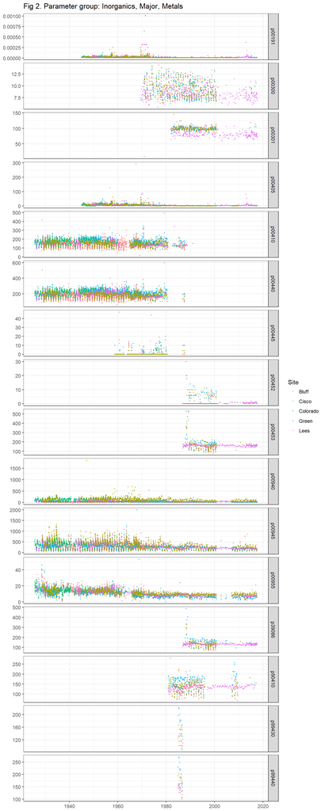

Table 2: List of parameters and description.

| parameter | description |
| --- | --- |
| p00945 | Sulfate, water, filtered, milligrams per liter |
| p99440 | Bicarbonate, water, unfiltered, inflection-point titration method (incremental titration method), field, milligrams per liter |
| p00955 | Silica, water, filtered, milligrams per liter as SiO2 |
| p90410 | Acid neutralizing capacity, water, unfiltered, fixed endpoint (pH 4.5) titration, laboratory, milligrams per liter as calcium carbonate |
| p00191 | Hydrogen ion, water, unfiltered, calculated, milligrams per liter |
| p00405 | Carbon dioxide, water, unfiltered, milligrams per liter |
| p00300 | Dissolved oxygen, water, unfiltered, milligrams per liter |
| p00410 | Acid neutralizing capacity, water, unfiltered, fixed endpoint (pH 4.5) titration, field, milligrams per liter as calcium carbonate |
| p39086 | Alkalinity, water, filtered, inflection-point titration method (incremental titration method), field, milligrams per liter as calcium carbonate |
| p00301 | Dissolved oxygen, water, unfiltered, percent of saturation |
| p00440 | Bicarbonate, water, unfiltered, fixed endpoint (pH 4.5) titration, field, milligrams per liter |
| p00445 | Carbonate, water, unfiltered, fixed endpoint (pH 8.3) titration, field, milligrams per liter |
| p00452 | Carbonate, water, filtered, inflection-point titration method (incremental titration method), field, milligrams per liter |
| p00453 | Bicarbonate, water, filtered, inflection-point titration method (incremental titration method), field, milligrams per liter |
| p00940 | Chloride, water, filtered, milligrams per liter |
| p99430 | Carbonate, water, unfiltered, inflection-point titration method (incremental titration method), field, milligrams per liter as calcium carbonate |

## Inorganics, Minor, Metals

A total of 16 parameters were measured for *Inorganics, Minor, Metals*. Figure 3 shows all parameter measurements by parameter and site. Table 3 provides the parameter code and description for Figure 3. Most of these parameters can be excluded from further analysis.

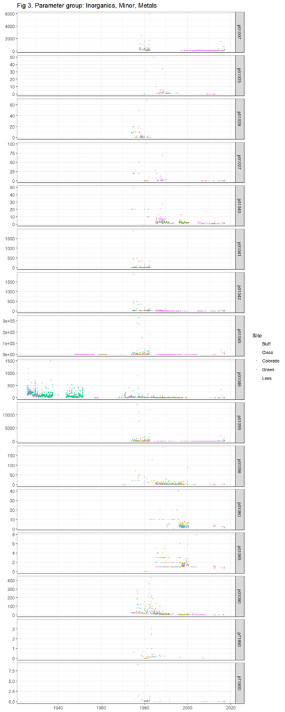

Table 3: List of parameters and description for Fig 3.

| parameter | description |
| --- | --- |
| p01040 | Copper, water, filtered, micrograms per liter |
| p01046 | Iron, water, filtered, micrograms per liter |
| p01041 | Copper, suspended sediment, recoverable, micrograms per liter |
| p01042 | Copper, water, unfiltered, recoverable, micrograms per liter |
| p01090 | Zinc, water, filtered, micrograms per liter |
| p01045 | Iron, water, unfiltered, recoverable, micrograms per liter |
| p71890 | Mercury, water, filtered, micrograms per liter |
| p01007 | Barium, water, unfiltered, recoverable, micrograms per liter |
| p01055 | Manganese, water, unfiltered, recoverable, micrograms per liter |
| p01056 | Manganese, water, filtered, micrograms per liter |
| p71900 | Mercury, water, unfiltered, recoverable, micrograms per liter |
| p01060 | Molybdenum, water, filtered, micrograms per liter |
| p01025 | Cadmium, water, filtered, micrograms per liter |
| p01026 | Cadmium, suspended sediment, recoverable, micrograms per liter |
| p01065 | Nickel, water, filtered, micrograms per liter |
| p01027 | Cadmium, water, unfiltered, micrograms per liter |